# Chapter6.Rmd

JL

7 12 2021

# Chapter 6: Analysis of longitudinal data

In this exercise, we are first going to analyse longitudinal data using the dataset called rats. Rats is a nutrition study conducted in three groups of rats. The three groups were on different diets and each animal’s body weight was recorded approximately weekly during a 9 week period. In the analyses, we are going to examine are the different diets having a statistically significant effect on the rats’ weight.

First, we are going to explore the data set graphically.

```r
#First activating the libraries needed in this exercise
library(ggplot2)
library(tidyr)
library(dplyr)
#Reading the data into R in long form, and checking the dimensions and structure of the data.
ratsL <- read.table("data/ratsL.txt")
dim(ratsL)
```

```
## [1] 176   5
```

```r
str(ratsL)
```

```
## 'data.frame':    176 obs. of  5 variables:
##  $ ID    : int  1 2 3 4 5 6 7 8 9 10 ...
##  $ Group : int  1 1 1 1 1 1 1 1 2 2 ...
##  $ WD    : chr  "WD1" "WD1" "WD1" "WD1" ...
##  $ Weight: int  240 225 245 260 255 260 275 245 410 405 ...
##  $ Time  : int  1 1 1 1 1 1 1 1 1 1 ...
```

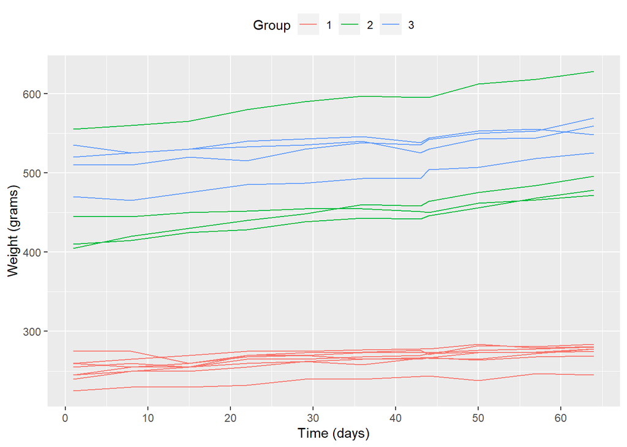

```r
#Converting categorical variables to factors (ID & Group)
ratsL$ID <- factor(ratsL$ID)
ratsL$Group <- factor(ratsL$Group)

#Drawing the first plot of the data set using standardized weight
ggplot(ratsL, aes(x = Time, y = Weight, group = ID)) +
  geom_line(aes(color = Group)) +
  scale_x_continuous(name = "Time (days)", breaks = seq(0, 60, 10)) +
  scale_y_continuous(name = "Weight (grams)") +
  theme(legend.position = "top")
```

In this first figure each rat is represented by one line. The colour of the line indicates the group the rat belongs to. From the plot we can see that the rats in Group 1 (red lines) are clearly lighter than rats in the other two groups. Rats in Group 2 (green lines) seems to be in the middle (expect for one rat, which is the heaviest of all), and Group 3 (blue lines) rats the heaviest. These differences in weight are present already at the baseline. Next, we will draw a similar figure with standardized weights.

```r
# Standardise the variable Weight
ratsL <- ratsL %>%
  group_by(Time) %>%
  mutate(stdweight = (Weight - mean(Weight))/sd(Weight) ) %>%
  ungroup()

# Glimpse the data
glimpse(ratsL)
```

```
## Rows: 176
## Columns: 6
## $ ID        <fct> 1, 2, 3, 4, 5, 6, 7, 8, 9, 10, 11, 12, 13, 14, 15, 16, 1, 2,~
## $ Group     <fct> 1, 1, 1, 1, 1, 1, 1, 1, 2, 2, 2, 2, 3, 3, 3, 3, 1, 1, 1, 1, ~
## $ WD        <chr> "WD1", "WD1", "WD1", "WD1", "WD1", "WD1", "WD1", "WD1", "WD1~
## $ Weight    <int> 240, 225, 245, 260, 255, 260, 275, 245, 410, 405, 445, 555, ~
## $ Time      <int> 1, 1, 1, 1, 1, 1, 1, 1, 1, 1, 1, 1, 1, 1, 1, 1, 8, 8, 8, 8, ~
## $ stdweight <dbl> -1.0011429, -1.1203857, -0.9613953, -0.8421525, -0.8819001, ~
```

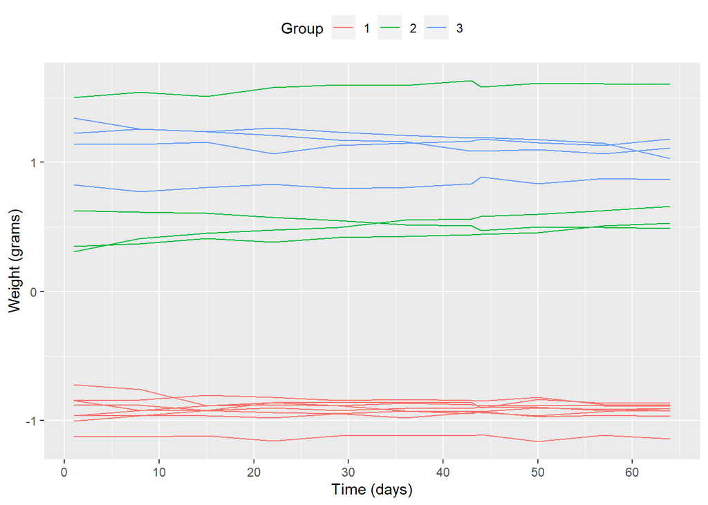

```r
#The figure again with standardized weight variables
ggplot(ratsL, aes(x = Time, y = stdweight, group = ID)) +
  geom_line(aes(color = Group)) +
  scale_x_continuous(name = "Time (days)", breaks = seq(0, 60, 10)) +
  scale_y_continuous(name = "Weight (grams)") +
  theme(legend.position = "top")
```

After standardizing the weight variable, the figure looks very similar to the first figure with unstandardized weights. The biggest difference might be that the rats’ weight does not seem to increase bytime any more, as it appeared to do in the first figure.

Next, we will draw a plot with group mean values (and standard errors).

```r
# Number of subjects (per group):
n <- 20

# Summary data with mean and standard error
ratsLS <- ratsL %>%
  group_by(Group, Time) %>%
 summarise( mean = mean(Weight), se = sd(Weight)/sqrt(n) ) %>%
  ungroup()
```

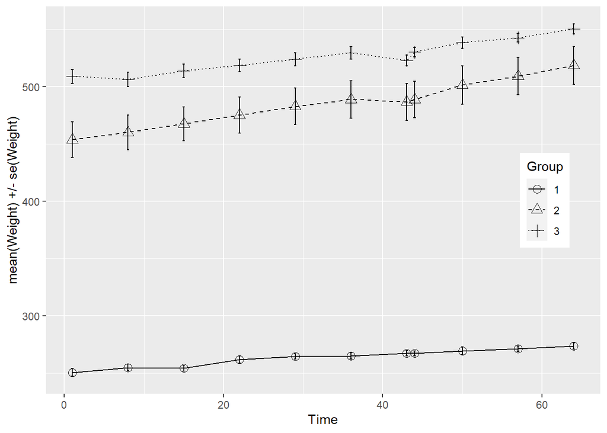

```r
# Plot the mean profiles
ggplot(ratsLS, aes(x = Time, y = mean, linetype = Group, shape = Group)) +
  geom_line() +
  scale_linetype_manual(values = c(1,2,3)) +
  geom_point(size=3) +
  scale_shape_manual(values = c(1,2,3)) +
  geom_errorbar(aes(ymin = mean - se, ymax = mean + se, linetype="1"), width=0.3) +
  theme(legend.position = c(0.9,0.5)) +
  scale_y_continuous(name = "mean(Weight) +/- se(Weight)")
```

```r
#Create a boxplot

# Create a summary data by Group and subject with mean as the summary variable (ignoring baseline week 0).
ratsL8s <- ratsL %>%
  filter(Time > 1) %>%
  group_by(Group, ID) %>%
  summarise( mean=mean(Weight) ) %>%
  ungroup()
# Glimpse the data
glimpse(ratsL8s)
```

```
## Rows: 16
## Columns: 3
## $ Group <fct> 1, 1, 1, 1, 1, 1, 1, 1, 2, 2, 2, 2, 3, 3, 3, 3
## $ ID    <fct> 1, 2, 3, 4, 5, 6, 7, 8, 9, 10, 11, 12, 13, 14, 15, 16
## $ mean  <dbl> 263.2, 238.9, 261.7, 267.2, 270.9, 276.2, 274.6, 267.5, 443.9, 4~
```

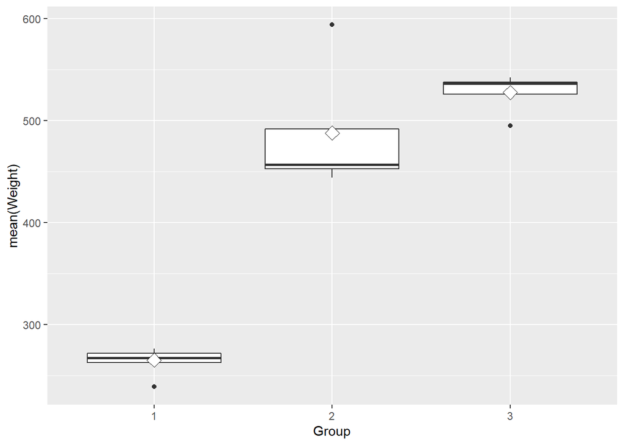

```r
# Draw a boxplot of the mean versus treatment
ggplot(ratsL8s, aes(x = Group, y = mean)) +
  geom_boxplot() +
  stat_summary(fun = "mean", geom = "point", shape=23, size=4, fill = "white") +
  scale_y_continuous(name = "mean(Weight)")
```

```r
# Create a new data by filtering the outlier and adjust the ggplot code the draw the plot again with the new data
#BPRSL8S1 <- BPRSL8S %>%
 # filter(mean < 60)
```

From the boxplot it can be seen that tehre are outliers in the data. In every group, there is one outlier (Group 1 < 250 g, Group 2 > 550 g, Group 3 < 500 g). These outliers could be removed before the analysis, because they might bias the conclusions made from the subsequent analysis, for example analysis of covariance.

```r
rats <- read.table("https://raw.githubusercontent.com/KimmoVehkalahti/MABS/master/Examples/data/rats.txt")

str(rats)
```

```
## 'data.frame':    16 obs. of  13 variables:
##  $ ID   : int  1 2 3 4 5 6 7 8 9 10 ...
##  $ Group: int  1 1 1 1 1 1 1 1 2 2 ...
##  $ WD1  : int  240 225 245 260 255 260 275 245 410 405 ...
##  $ WD8  : int  250 230 250 255 260 265 275 255 415 420 ...
##  $ WD15 : int  255 230 250 255 255 270 260 260 425 430 ...
##  $ WD22 : int  260 232 255 265 270 275 270 268 428 440 ...
##  $ WD29 : int  262 240 262 265 270 275 273 270 438 448 ...
##  $ WD36 : int  258 240 265 268 273 277 274 265 443 460 ...
##  $ WD43 : int  266 243 267 270 274 278 276 265 442 458 ...
##  $ WD44 : int  266 244 267 272 273 278 271 267 446 464 ...
##  $ WD50 : int  265 238 264 274 276 284 282 273 456 475 ...
##  $ WD57 : int  272 247 268 273 278 279 281 274 468 484 ...
##  $ WD64 : int  278 245 269 275 280 281 284 278 478 496 ...
```

```r
# Add the baseline from the original data as a new variable to the summary data
ratsL8s2 <- ratsL8s %>%
  mutate(baseline = rats$WD1)

str(ratsL8s2)
```

```
## tibble [16 x 4] (S3: tbl_df/tbl/data.frame)
##  $ Group   : Factor w/ 3 levels "1","2","3": 1 1 1 1 1 1 1 1 2 2 ...
##  $ ID      : Factor w/ 16 levels "1","2","3","4",..: 1 2 3 4 5 6 7 8 9 10 ...
##  $ mean    : num [1:16] 263 239 262 267 271 ...
##  $ baseline: int [1:16] 240 225 245 260 255 260 275 245 410 405 ...
```

```r
# Fit the linear model with the mean as the response
fit <- lm(mean ~ baseline + Group, data = ratsL8s2)

# Compute the analysis of variance table for the fitted model with anova()
anova(fit)
```

```
## Analysis of Variance Table
##
## Response: mean
##           Df Sum Sq Mean Sq   F value   Pr(>F)
## baseline   1 253625  253625 1859.8201 1.57e-14 ***
## Group      2    879     439    3.2219  0.07586 .
## Residuals 12   1636     136
## ---
## Signif. codes:  0 '***' 0.001 '**' 0.01 '*' 0.05 '.' 0.1 ' ' 1
```